# Projekt

Izabela Guła

2024-03-25

## Temat projektu

Tematem projektu jest interesujący mnie aspekt zmiany środowiska naturalnego, szczególnie zmian klimatu. Postanowiłam zbadać i przeanalizować, jakie czynniki wpływają na emisję dwutlenku węgla, podtlenku azotu oraz na wykorzystanie odnawialnych źródeł energii. Wybrałam kilka zmiennych, które moim zdaniem mogą mieć istotny wpływ na te aspekty. Moim celem jest zbadanie korelacji i powiązań między wybranymi zmiennymi a emisją gazów cieplarnianych oraz zużyciem energii odnawialnej. W większości będę się posługiwać wykresami i wyciągać z nich interesujące mnie kwestie i wnioski. Czy wybrane zmienne rzeczywiście mają wpływ na emisje gazów cieplarnianych i korzystanie z energii odnawialnej? Oto co zamierzam zbadać.

## Pakiety, których będę używać

```r
library(dplyr)
library(countrycode)
library(mice)
library(tidyr)
library(gapminder)
library(ggplot2)
library(RColorBrewer)
library(ggrepel)
library(gridExtra)
library(cowplot)
```

## Zapoznanie się ze zmiennymi

**Populacja (pop)**

Całkowita populacja oznaczająca liczbę mieszkańców na terytorium danego państwa.

**PKB per capita (PKB)**

Produkt krajowy brutto na osobę. Dane skorygowane pod względem różnic w sile nabywczej. PKB wyrażone jest w międzynarodowych dolarach, skorygowane pod względem inflacji bazując na roku 2017 - parytet siły nabywczej bazowany jest na ICP z roku 2017.

**Procentowy udział rolnictwa w PKB (agriculture)**

Jest to procentowy udział rolnictwa w wartości PKB. Obejmuje on leśnictwo, łowiectwo i rybołówstwo, a także uprawę roślin i produkcję zwierzęcą.

**Poziom urbanizacji (urban)**

Jest to procentowy udział mieszkańców miast w ogólnej liczbie ludności.

**Emisja podtlenku azotu na osobę (nitrous_per_capita_individua)**

Jest to emisja gazu cieplarnego podtlenku azotu na osobę. Należy on do głównych gazów cieplarnianych. Jego emisja pochodzi głównie z rolnictwa. Będąc trzecim najważniejszym długotrwałym gazem cieplarnianym, podtlenek azotu w znacznym stopniu przyczynia się do globalnego ocieplenia i jest substancją, która znacznie zubaża ozon stratosferyczny. Zmienna została stworzona przeze mnie, dzieląc ogólną emisję podtlenku azotu przez populacje. Ogólna emisje również zostawiłam w tabeli, ponieważ uznałam, że może przyda się w któryś obliczeniach.

**Emisja dwutlenku węgla na osobę (CO2)**

Emisja dwutlenku węgla pochodzącego ze spalania paliw kopalnianych w tonach na osobę (metryczne tony dwutlenku węgla na osobę).

**Powierzchnia terenów leśnych (woods)**

Procent całkowitej powierzchni terenów leśnych wyrażony w procentach.

**Produkcja energii odnawialnej (renewable)**

Procent użycia energii odnawialnej w stosunku do całkowitego użycia energii.

**Ślad materiałowy (material)**

Ślad materiałowy to całkowita ilość surowców, takich jak biomasa, paliwa kopalne, rudy metali i rudy niemetali, wydobywana co roku w celu zaspokojenia zapotrzebowania konsumpcyjnego krajów, wyrażona w tonach.

**Procentowy udział przemysłu w PKB (industry)**

Jest to procentowy udział przemysłu w PKB. Obejmuje wartość dodaną w górnictwie, przemyśle przetwórczym (również wykazywanym jako odrębna podgrupa), budownictwie, energii elektrycznej, wodzie i gazie.

**Kontynenty**

Postanowiłam podzielić świat na 4 części: Ameryki, Azję, Europe i Afrykę. Postanowiłam usunąć Australię i Oceanie z powodu brakujących i bardzo odstających wartości.

## Zapoznanie się ze strukturą pliku

Zestaw danych został stworzony z gapmindera, poprzez połączenie ze sobą wybranych zmiennych.

```r
str(dane)
```

```
## 'data.frame':    1744 obs. of  14 variables:
##  $ kraj                         : chr  "UAE" "Argentina" "Austria" "Burundi" ...
##  $ rok                          : chr  "1990" "1990" "1990" "1990" ...
##  $ pop                          : num  1.90e+06 3.26e+07 7.68e+06 5.48e+06 5.13e+06 9.13e+06 1.07e+08 8.77e+06 5.17e+05 2.71e+05 ...
##  $ PKB                          : num  75100 14300 37800 1280 2240 1170 1640 12600 25000 37900 ...
##  $ agriculture                  : num  1.06 8.12 3.1 51.1 34.7 28 30.5 17.7 0.949 2.21 ...
##  $ urban                        : num  79.1 87 63 6.27 34.5 13.8 19.8 66.4 88.1 79.8 ...
##  $ nitrous                      : num  514 35100 4980 719 1550 4370 14700 8330 50.3 18.9 ...
##  $ CO2                          : num  28.3 3.43 8.08 0.0384 0.137 0.0662 0.137 8.66 25 7.18 ...
##  $ woods                        : num  3.45 12.9 45.8 10.8 42.9 28.2 14.8 30.1 0.32 50.9 ...
##  $ renewable                    : num  0 35.4 66.2 98.2 0 4.89 11.4 4.46 0 0 ...
##  $ material                     : num  64.8 11.1 22.2 3.27 4.04 3.32 1.45 13.9 28.9 43.4 ...
##  $ industry                     : num  58.9 36 29.6 17.3 12.5 20.4 20.1 51.3 45.7 14.2 ...
##  $ kontynent                    : chr  "Asia" "Americas" "Europe" "Africa" ...
##  $ nitrous_per_capita_individual: num  0.000271 0.001077 0.000648 0.000131 0.000302 ...
##  - attr(*, "na.action")= 'omit' Named int [1:245] 1 2 3 6 8 10 17 18 25 26 ...
##   ..- attr(*, "names")= chr [1:245] "1" "2" "3" "6" ...
```

## Poznanie zmiennych i ich rozkładu

W tym punkcie, za pomocą prostych statystyk i wykresów (w większości liniowych) poznam rozkład każdej zmiennej, co pozwoli wyciągnąć mi ciekawe wnioski i pomoże mi w stawianiu późniejszych hipotez.

### Populacja

```r
population_in_thousands <- dane$pop/1000
summary(population_in_thousands)
```

```
##    Min. 1st Qu.  Median    Mean 3rd Qu.    Max.
##     183    4520   10350   44227   30325 1390000
```

```r
max_population <- max(dane$pop)
min_population <- min(dane$pop)

max_population_country <- filter(dane, pop == max_population) %>%
  mutate(population_in_thousands = pop/1000) %>%
  select(kraj, population_in_thousands)

min_population_country <- filter(dane, pop== min_population) %>%
  mutate(population_in_thousands = pop/1000) %>%
  select(kraj, population_in_thousands)

result_table <- bind_rows(max_population_country, min_population_country)
result_table
```

| kraj | population_in_thousands |
| --- | --- |
| China | 1390000 |
| Belize | 183 |

### PKB per capita

```r
summary(dane$PKB)
```

```
##    Min. 1st Qu.  Median    Mean 3rd Qu.    Max.
##     482    3430    9345   16523   23525  117000
```

```r
sd(dane$PKB)
```

```
## [1] 18643.83
```

Jak można zauważyć, odchylenie standardowe PKB per capita jest duże, jednak jest to normalne, ponieważ w mojej bazie danych posiadam państwa bogate, jak i biedne.

Sprawdzę jednak, jak wygląda sytuacja, gdy pogrupujemy państwa na kontynenty.

```r
pkb_dane <- dane %>%
  group_by(kontynent) %>%
  summarise(mean = mean(PKB), sd = sd(PKB))
pkb_dane
```

| kontynent | mean | sd |
| --- | --- | --- |
| Africa | 4416.284 | 5348.93 |
| Americas | 14065.929 | 11387.03 |
| Asia | 17083.136 | 20930.42 |
| Europe | 32098.910 | 18960.26 |

Największe różnice w wartości PKB można zauważyć w Azji, najmniejsze w Afryce, jednak PKB w Afryce posiada najniższą średnia arytmetyczna.

### Udział rolnictwa w PKB

```r
summary(dane$agriculture)
```

```
##    Min. 1st Qu.  Median    Mean 3rd Qu.    Max.
##  0.0333  3.5350  9.7650 13.9086 21.6000 79.0000
```

```r
max_rolnictwo <- max(dane$agriculture)
min_rolnictwo <- min(dane$agriculture)

max_rolnictwo_country <- filter(dane, agriculture == max_rolnictwo) %>%
  select(kraj, agriculture)

min_rolnictwo_country <- filter(dane, agriculture == min_rolnictwo) %>%
  select(kraj, agriculture)

wynik_rolnictwo <- bind_rows(max_rolnictwo_country, min_rolnictwo_country)
wynik_rolnictwo
```

| kraj | agriculture |
| --- | --- |
| Liberia | 79.0000 |
| Singapore | 0.0333 |

### Współczynnik urbanizacji

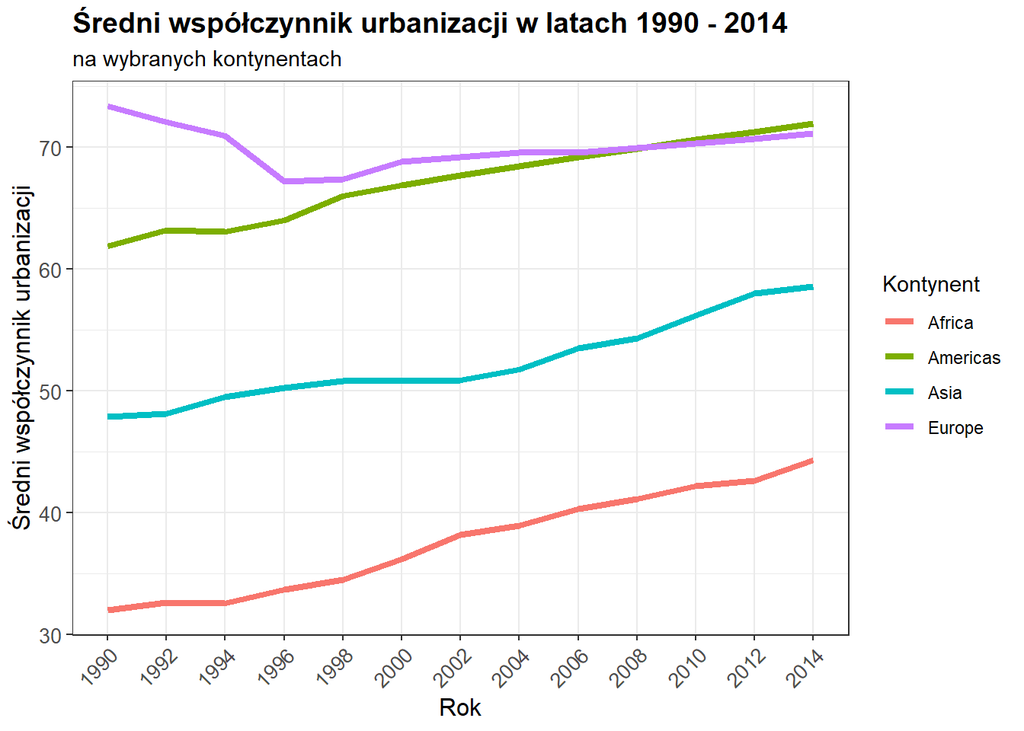

```r
wykres_urban <- dane %>%
  group_by(kontynent, rok) %>%
  summarize(mean_urban = mean(urban, na.rm = TRUE))

ggplot(wykres_urban, aes(x = rok, y = mean_urban, color = kontynent, group = kontynent)) +
  geom_line(size = 1.5) +
  theme_bw() +
  labs(title = "Średni współczynnik urbanizacji w latach 1990 - 2014",
       subtitle = "na wybranych kontynentach",
       color = "Kontynent") +
  xlab("Rok") +
  ylab("Średni współczynnik urbanizacji") +
  theme(axis.text=element_text(size=10),
        axis.title=element_text(size=14),
        axis.text.y = element_text(size=10),
        axis.text.x = element_text(angle = 45, hjust = 1),
        axis.title.x = element_text(size = 12),
        axis.title.y = element_text(size = 12),
        plot.title = element_text(size = 14, face = "bold"))
```

Uważam, że urbanizacja była do przewidzenia. Państwa na wszystkich kontynentach coraz bardziej się rozwijają i coraz więcej osób mieszka w miastach. Spodziewałam się najmniejszego wyniku w Afryce, natomiast najwyższego wyniku w Europie i Amerykach.

### Emisja podtlenku azotu na osobę

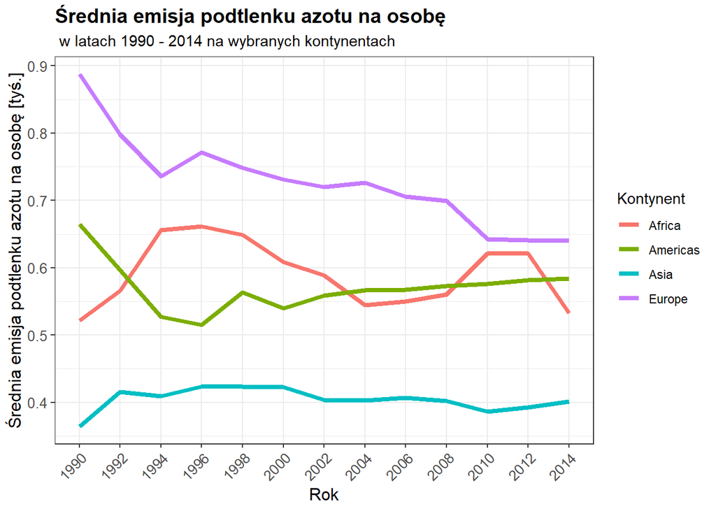

```r
wykres_nitrous <- dane %>%
  group_by(kontynent, rok) %>%
  summarize(mean_nitrous = mean(nitrous_per_capita_individual, na.rm = TRUE))

ggplot(wykres_nitrous, aes(x = rok, y = mean_nitrous, color = kontynent, group = kontynent)) +
  geom_line(size = 1.5) +
  theme_bw() +
  labs(title = "Średnia emisja podtlenku azotu na osobę",
       subtitle = " w latach 1990 - 2014 na wybranych kontynentach",
       color = "Kontynent") +
  xlab("Rok") +
  ylab("Średnia emisja podtlenku azotu na osobę [tyś.]")+
  theme(axis.text=element_text(size=10),
        axis.title=element_text(size=14),
        axis.text.y = element_text(size=10),
        axis.text.x = element_text(angle = 45, hjust = 1),
        axis.title.x = element_text(size = 12),
        axis.title.y = element_text(size = 12),
        plot.title = element_text(size = 14, face = "bold")) +
 scale_y_continuous(labels = scales::number_format(scale = 1e3))
```

Aby ułatwić odczytywanie wykresu, zmieniłam formatowanie wartości dla emisji podtlenku azotu, są to małe liczby, dlatego dla ułatwienia są one wyświetlane w tysiącach. Tutaj powstałe wartości są bardzo ciekawe. Po pierwsze najwięcej podtlenku azotu produkuje Europa, Afryka i Ameryki. Natomiast o wiele mniejszą emisję niż pozostałe kontynenty możemy zaobserwować w Azji, nie sądziłam, że Azja będzie tutaj wartością odstającą ze względu na wiele rozwiniętych państw, które potencjalnie mogą być odpowiedzialne za wysoką emisję gazów cieplarnianych.

### Emisja dwutlenku węgla na osobę

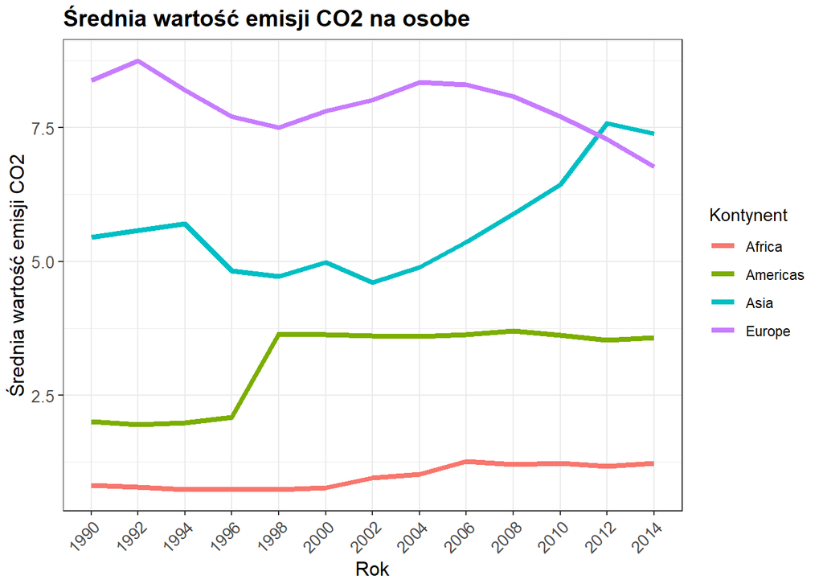

```r
wykres_CO2 <- dane %>%
  group_by(kontynent, rok) %>%
  summarize(mean_CO2 = mean(CO2, na.rm = TRUE))

ggplot(wykres_CO2, aes(x = rok, y = mean_CO2, color = kontynent, group = kontynent)) +
  geom_line(size = 1.5) +
  theme_bw() +
  labs(title = "Średnia wartość emisji CO2 na osobe",
       color = "Kontynent") +
  xlab("Rok") +
  ylab("Średnia wartość emisji CO2") +
  theme(axis.text=element_text(size=10),
        axis.title=element_text(size=14),
        axis.text.y = element_text(size=10),
        axis.text.x = element_text(angle = 45, hjust = 1),
        axis.title.x = element_text(size = 12),
        axis.title.y = element_text(size = 12),
        plot.title = element_text(size = 14, face = "bold"))
```

Z wykresu wynika, że najwyższą średnią emisję CO2 posiadają Azja i Europa. Cieszy mnie tendencja spadkowa w Europie w ciągu ostatnich lat. Najniższe wartości występują w Afryce, co według mnie było do przewidzenia.

Postanowiłam sprawdzić jakie państwa posiadają najwyższa średnią emisje CO2.

```r
highest_emission <- dane %>%
  group_by(kraj) %>%
  summarize(srednia_CO2 = mean(CO2)) %>%
  top_n(n = 5, wt = srednia_CO2)
highest_emission
```

| kraj | srednia_CO2 |
| --- | --- |
| Bahrain | 23.43750 |
| Kuwait | 27.86667 |
| Luxembourg | 22.23750 |
| Qatar | 42.80000 |
| UAE | 26.45385 |

Pokazane wartości bardzo mnie zaciekawiły. Po sprawdzeniu okazało się, że są to państwa m.in. Bliskiego Wschodu, ale co łączy te wszystkie państwa ? Okazuje się, że są one znane z wydobycia ropy naftowej czy gazu ziemnego. Wydobycie ropy naftowej ma związane ze sobą emisje dwutlenku węgla i inne gazów cieplarnianych. Proces wydobycia ropy naftowej oraz jej produkcji, transportu i rafinacji generuje emisję CO2 do atmosfery. Stąd już wiemy, kto jest odpowiedzialny za największą emisję dwutlenku węgla do atmosfery.

### Powierzchnia terenów leśnych

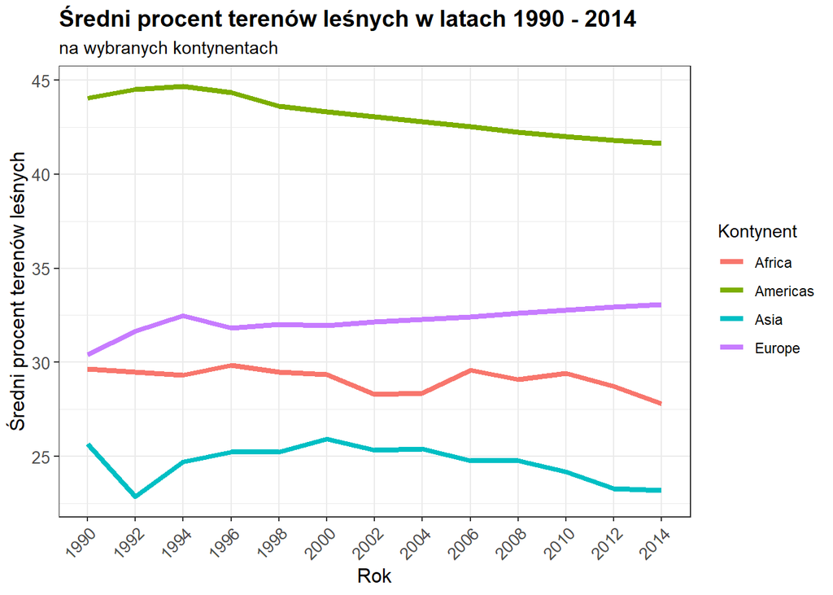

```r
wykres_woods <- dane %>%
  group_by(kontynent, rok) %>%
  summarize(mean_woods = mean(woods, na.rm = TRUE))

ggplot(wykres_woods, aes(x = rok, y = mean_woods, color = kontynent, group = kontynent)) +
  geom_line(size = 1.5) +
  theme_bw() +
  labs(title = "Średni procent terenów leśnych w latach 1990 - 2014",
       subtitle = "na wybranych kontynentach",
       color = "Kontynent") +
  xlab("Rok") +
  ylab("Średni procent terenów leśnych") +
  theme(axis.text=element_text(size=10),
        axis.title=element_text(size=14),
        axis.text.y = element_text(size=10),
        axis.text.x = element_text(angle = 45, hjust = 1),
        axis.title.x = element_text(size = 12),
        axis.title.y = element_text(size = 12),
        plot.title = element_text(size = 14, face = "bold"))
```

Najwięcej terenów leśnych jest na kontynentach Ameryki Północnej i Południowej. Rzeczą, która mnie zaskoczyła to, że w Azji występuje tak mało terenów leśnych. Jednak co nie jest już optymistyczne to spadek udziału terenów leśnych w Afryce. Jestem ciekawa, jakie są to państwa i czym jest spowodowany ten spadek.

```r
africa_woods <- dane %>%
  filter(kontynent == "Africa") %>%
  group_by(kraj) %>%
  summarize(zmiana = max(woods) - min(woods)) %>%
  top_n(n = 5, wt = zmiana)
africa_woods
```

| kraj | zmiana |
| --- | --- |
| Benin | 12.4 |
| Cote d'Ivoire | 13.6 |
| Gambia | 13.6 |
| Malawi | 10.7 |
| Tanzania | 10.1 |

W niektórych państwach jest to spadek o ponad 10 puktów procentowych. Okazuje się, że te państwa leżą na terenach, gdzie występują lasy tropikalne. Duża część Afryki została poddana deforestacji w XX wieku. Była ona głównie efektem rozwoju rolnictwa i handlu, w którym przeważały produkty rolne, ale także przesiedleń w wyniku konfliktów. Szybki rozwój miast, szczególnie wzdłuż wybrzeża, także był przyczyną masowego wylesiania.

### Odnawialne źródła energii

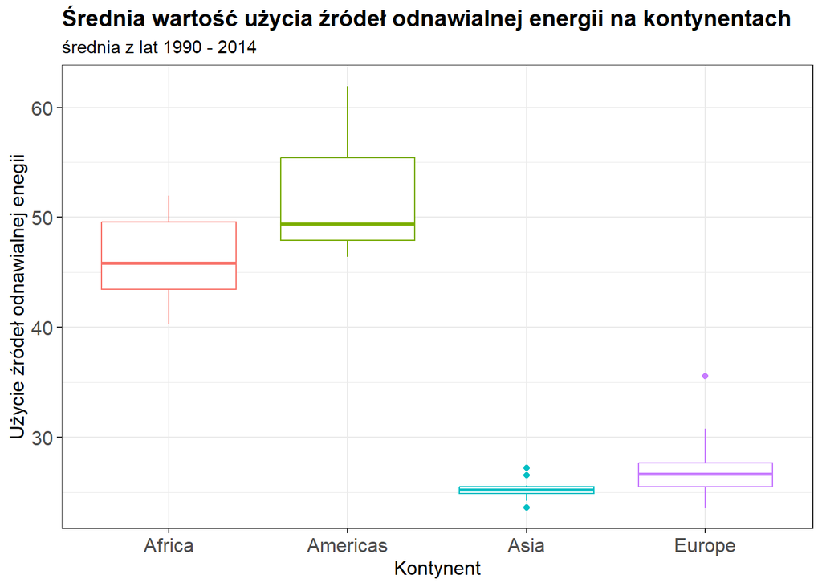

```r
wykres_renewable <- dane %>%
  group_by(kontynent, rok) %>%
  summarize(mean_ren = mean(renewable))
ggplot(wykres_renewable, aes(x = as.factor(kontynent), y = mean_ren, color = kontynent)) +
  geom_boxplot() +
  theme_bw() +
  theme(legend.position="none") +
  labs(title = "Średnia wartość użycia źródeł odnawialnej energii na kontynentach",
       subtitle = "średnia z lat 1990 - 2014",
       color = "Kontynent") +
  xlab("Kontynent") +
  ylab("Użycie źródeł odnawialnej enegii") +
  theme(axis.text=element_text(size=12),
        plot.title = element_text(size = 14, face = "bold"),
        axis.title=element_text(size=12))
```

```r
srednia_renewable <- mean(dane$renewable[dane$rok >= 1990 & dane$rok <= 2014])
najwyzsza_wartosc <- dane$kraj[which.max(dane$renewable)]
najwyzsza_wartosc
```

```
## [1] "Ghana"
```

### Wydobycie surowców

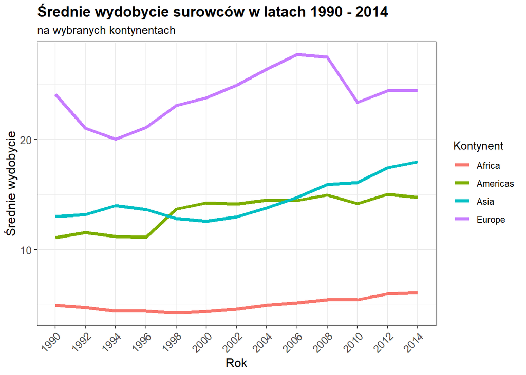

```r
wykres_materialy <- dane %>%
  group_by(kontynent, rok) %>%
  summarize(mean_materialy = mean(material, na.rm = TRUE))

ggplot(wykres_materialy, aes(x = rok, y = mean_materialy, color = kontynent, group = kontynent)) +
  geom_line(size = 1.5) +
  theme_bw() +
  labs(title = "Średnie wydobycie surowców w latach 1990 - 2014",
       subtitle = "na wybranych kontynentach",
       color = "Kontynent") +
  xlab("Rok") +
  ylab("Średnie wydobycie") +
  theme(axis.text=element_text(size=10),
        axis.title=element_text(size=14),
        axis.text.y = element_text(size=10),
        axis.text.x = element_text(angle = 45, hjust = 1),
        axis.title.x = element_text(size = 12),
        axis.title.y = element_text(size = 12),
        plot.title = element_text(size = 14, face = "bold"))
```

Powyższy wykres przedstawia średnie wydobycie surowców na kontynentach. Szczerze nie spodziewałam się, że Europa będzie tutaj tak wysoko, ponieważ myślałam, że na innych kontynentach wydobywa się więcej surowców. Nie spodziewałam się również, że Afryka znajdzie się najniżej. Afryka jest kontynentem bardzo bogatym w zasoby naturalne, których wielkość właściwie nie została oszacowana. Stosunkowo dobrze rozwiniętą gałęzią przemysłu jest wydobycie surowców, które w niektórych krajach wytwarza ponad 40% PKB. Jednakże gałąź ta jest bardzo wrażliwa na wahania cen. Dodatkowym problemem są niepokoje, powszechna korupcja i słabo rozwinięta infrastruktura.

## Hipotezy

### Hipoteza 1

#### Badanie mające na celu sprawdzenie zależności między wielkością PKB per capita a emisją dwutlenku węgla i emisją podtlenku azotu. Przeprowadzenie analizy, sprawdzającej, czy kraje z większym PKB per capita emitują więcej gazów cieplarnianych.

Osobiście uważam, że PKB może mieć wpływ na emisje dwutlenku węgla i podtlenku azotu. Myślę, że państwa posiadające wyższe PKB emitują więcej gazów cieplarnianych do atmosfery.

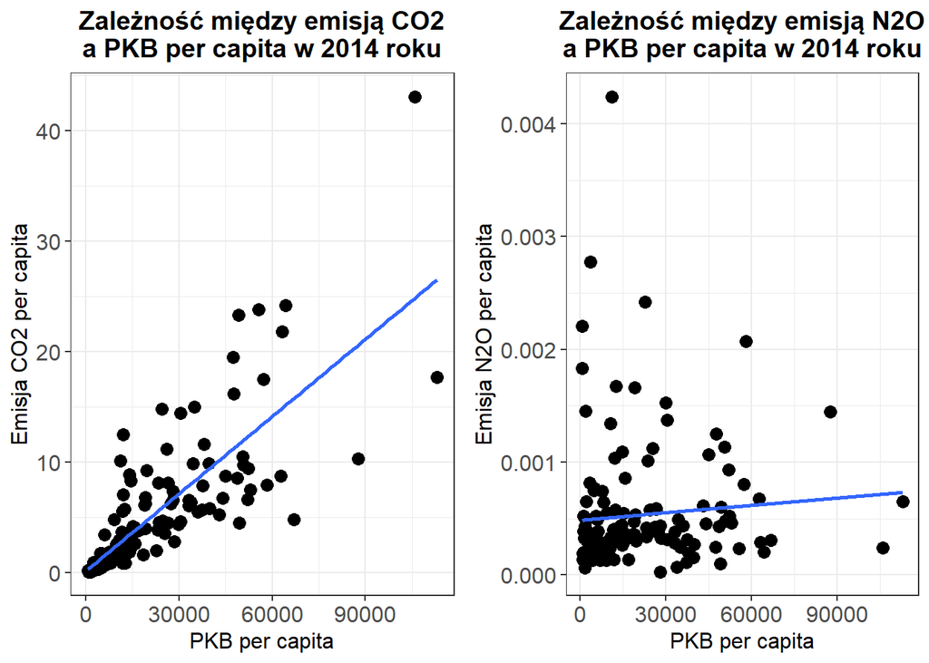

```r
PKB_CO2 <- ggplot(dane %>% filter(rok == 2014), aes(x = PKB, y = CO2)) +
  geom_point(size = 3) +
  geom_smooth(method = "lm", se = FALSE) +
  labs(
    title = "Zależność między emisją CO2
a PKB per capita w 2014 roku",
    x = "PKB per capita",
    y = "Emisja CO2 per capita",
  ) +
  theme_bw() +
  theme(
    axis.text = element_text(size = 12),
    axis.title = element_text(size = 12),
    plot.title = element_text(size = 14, face = "bold", hjust = 0.5)
  )

PKB_nitrous <- ggplot(dane %>% filter(rok == 2014), aes(x = PKB, y = nitrous_per_capita_individual)) +
  geom_point(size = 3) +
  geom_smooth(method = "lm", se = FALSE) +
  labs(
    title = "Zależność między emisją N2O
a PKB per capita w 2014 roku",
    x = "PKB per capita",
    y = "Emisja N2O per capita",
  ) +
  theme_bw() +
  theme(
    axis.text = element_text(size = 12),
    axis.title = element_text(size = 12),
    plot.title = element_text(size = 14, face = "bold",hjust = 0.5)
  )

plot_grid(PKB_CO2, PKB_nitrous, nrow = 1)
```

Dodatkowo sprawdzę korelacje między zmiennymi, używając funkcji `cor()`.

```r
cor(dane$PKB, dane$CO2)
```

```
## [1] 0.8358626
```

```r
cor(dane$PKB, dane$nitrous_per_capita_individual)
```

```
## [1] 0.1097965
```

### Hipoteza 2

#### Badanie mające na celu sprawdzenie zależności między wielkością udziału rolnictwa w PKB per capita a emisją podtlenku azotu. Przeprowadzenie analizy, sprawdzającej, czy kraje z większym udziałem rolnictwa w PKB per capita emitują więcej podtlenku azotu.

Z informacji o podtlenku azotu dowiedziałam się, że duży wpływ na emisję podtlenku azotu na rolnictwo, dlatego spodziewam się, że wyższy udział rolnictwa będzie się wiązać z większą emisja N2O. Dodatkowo sprawdzę, jak zmieniał się udział rolnictwa w PKB na przestrzeni lat.

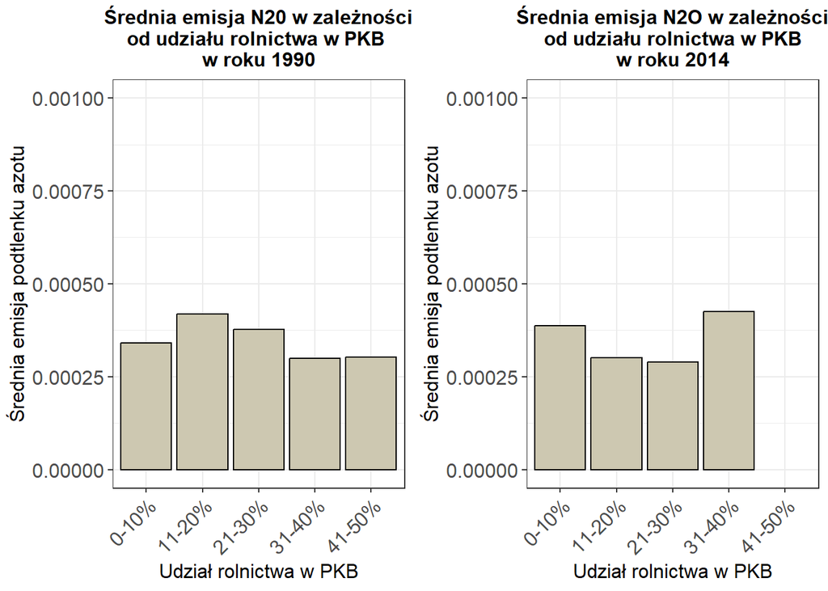

```r
agriculture_data_1990 <- dane %>%
  filter(rok == 1990) %>%
  mutate(group = cut(agriculture, breaks = c(0, 10, 20, 30, 40, 50), labels = c("0-10%", "11-20%", "21-30%", "31-40%", "41-50%"))) %>%
  na.omit()

agriculture_data_2014 <- dane %>%
  filter(rok == 2014) %>%
  mutate(group = cut(agriculture, breaks = c(0, 10, 20, 30, 40, 50), labels = c("0-10%", "11-20%", "21-30%", "31-40%", "41-50%"))) %>%
  na.omit()

agriculture_nitr_1990 <- ggplot(agriculture_data_1990, aes(x = group, y = nitrous_per_capita_individual)) +
  stat_summary(fun = mean, geom = "bar", fill = "cornsilk3", position = "dodge", colour = "black") +
  labs(
    title = "Średnia emisja N20 w zależności
od udziału rolnictwa w PKB
w roku 1990",
    x = "Udział rolnictwa w PKB",
    y = "Średnia emisja podtlenku azotu"
  ) +
  theme_bw() +
  theme(    axis.text = element_text(size = 12),
    axis.title = element_text(size = 12),
    plot.title = element_text(size = 12, face = "bold", hjust = 0.5),
    axis.text.x = element_text(angle = 45, hjust = 1)) +
  scale_x_discrete(drop = FALSE)+
  ylim(0, 0.001)

agriculture_nitr_2014 <- ggplot(agriculture_data_2014, aes(x = group, y = nitrous_per_capita_individual)) +
  stat_summary(fun = mean, geom = "bar", fill = "cornsilk3", position = "dodge", colour = "black") +
  labs(
    title = "Średnia emisja N2O w zależności
od udziału rolnictwa w PKB
w roku 2014",
    x = "Udział rolnictwa w PKB",
    y = "Średnia emisja podtlenku azotu"
  ) +
  theme_bw() +
  theme(
    axis.text = element_text(size = 12),
    axis.title = element_text(size = 12),
    plot.title = element_text(size = 12, face = "bold", hjust = 0.5),
    axis.text.x = element_text(angle = 45, hjust = 1)) +
  scale_x_discrete(drop = FALSE) +
  ylim(0, 0.001)

plot_grid( agriculture_nitr_1990, agriculture_nitr_2014, nrow = 1)
```

Co możemy wywnioskować z tego wykresu. Po pierwsze, w 2014 w zbiorze danych nie ma już państw, które mają udział rolnictwa w PKB powyżej 40%. W 1990 roku rozkład średniej emisji podtlenku azotu był bardzo podobny w zależności od udziału rolnictwa w PKB. Natomiast w 2014 roku możemy zauważyć, że państwa posiadające udział rolnictwa między 31% a 40% mają najwyższą emisję tego gazu cieplarnianego. Rolnictwo ma istotny wpływ na emisję podtlenku azotu, ponieważ jest on głównie związany z procesami związanej z nawożeniem azotowym i praktykami związanymi z gospodarką glebową. Okazuje się, że największy wpływ na jego emisję ma używanie nawozów azotanowych oraz hodowla zwierząt. Nawozy azotowe, takie jak mocznik, azotany i azotany amonowe, są powszechnie stosowane w rolnictwie, aby zwiększyć plony upraw poprzez dostarczenie roślinom azotu. Jednakże procesy związane z rozkładem tych nawozów w glebie mogą prowadzić do emisji N2O. Procesy nazywane denitryfikacją i nitryfikacją mogą prowadzić do emisji tego gazu do atmosfery. Natomiast jeśli chodzi o hodowlę zwierząt, w żołądkach zwierząt hodowlanych, takich jak krowy i owce, również przyczynia się do emisji N2O. Proces ten jest związany z metabolizmem azotowym zwierząt i może prowadzić do emisji N2O w postaci gazów wypuszczanych przez zwierzęta. Nie do końca zauważam tendencję wzrostową, jeżeli chodzi o większy udział rolnictwa i większą emisję N2O, dlatego sprawdzę jeszcze jedną rzecz.

```r
dane_1990 <- dane %>%
  filter(rok == 1990)

dane_2014 <- dane %>%
  filter(rok == 2014)

mean_agriculture_1990 <- mean(dane_1990$agriculture)
mean_agriculture_2014 <- mean(dane_2014$agriculture)
mean_nitrous_1990 <- mean(dane_1990$nitrous_per_capita_individual)
mean_nitrous_2014 <- mean(dane_2014$nitrous_per_capita_individual)

wyniki_agri_nitr <- data.frame(
  Rok = c("1990", "2014"),
  Średnia_agriculture = c(mean_agriculture_1990, mean_agriculture_2014),
  Średnia_nitrous = c(mean_nitrous_1990, mean_nitrous_2014)
)

print(wyniki_agri_nitr)
```

```
##    Rok Średnia_agriculture Średnia_nitrous
## 1 1990            18.41313    0.0005564651
## 2 2014            10.74020    0.0005298706
```

Średni udział rolnictwa zmniejszył się, praktycznie o połowę. Mimo to, przez 24 lat rolnictwo przeszło wiele zmian zarówno na poziomie technologicznym, jak i społeczno-gospodarczym. Rozwój technologii w rolnictwie był niezwykle znaczący. Zastosowanie nowoczesnych maszyn rolniczych, technik uprawowych, nawożenia, ochrony roślin czy systemów nawadniających znacząco zwiększyło wydajność produkcji rolnej. Natomiast hodowla zwierząt bardzo zwiększyła się oraz stała się bardziej zintensyfikowana, co oznacza większe skupienie się na zwiększeniu produkcji mięsa, mleka, jajek i innych produktów zwierzęcych. Wykorzystuje się bardziej wydajne rasy zwierząt, a także wprowadza się nowoczesne technologie w żywieniu, hodowli i opiece nad zwierzętami. Prawdopodobnie takie czynniki, mimo zmniejszenia średniego udziału rolnictwa na świecie, wpływają na to, że średnia emisja tego gazu cieplarnianego się nie zmniejsza. Podsumowując, mogę stwierdzić, że na podstawie zmniejszającego się średniego udziału rolnictwa i mniej więcej podobnej średniej emisji podtlenku azotu, wielkość udziału rolnictwa w PKB może nie mieć wpływu na emisję tego gazu cieplarnianego. Wpływ na wielkość emisji mogą mieć inne czynniki takie jak np. zmiana sposobu uprawiania rolnictwa lub inne czynniki niezależne od rolnictwa.

### Hipoteza 3

#### Badanie mające na celu sprawdzenie zależności między wielkością udziałem przemysłu w PKB per capita a emisją CO2. Przeprowadzenie analizy, sprawdzającej, czy kraje z większym udziałem przemysłu w PKB per capita emitują więcej gazów cieplarnianych.

Jako iż bardzo dużo mówi się o tym, jak przemysł wpływa na emisję dwutlenku węgla, postanowiłam to sprawdzić. Osobiście uważam, że im państwo ma większy udział przemysłu w PKB, tym emituje więcej CO2 do atmosfery.

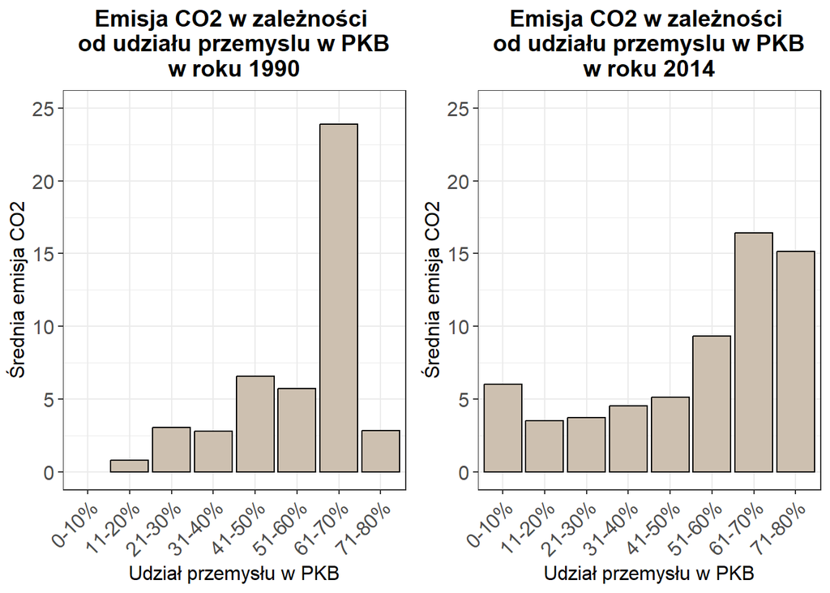

```r
industry_data_1990 <- dane %>%
  filter(rok == 1990) %>%
  mutate(group = cut(industry, breaks = c(0, 10, 20, 30, 40, 50, 60,70,80), labels = c("0-10%", "11-20%", "21-30%", "31-40%", "41-50%","51-60%", "61-70%", "71-80%"))) %>%
  na.omit()

industry_data_2014 <- dane %>%
  filter(rok == 2014) %>%
  mutate(group = cut(industry, breaks = c(0, 10, 20, 30, 40, 50, 60,70,80), labels = c("0-10%", "11-20%", "21-30%", "31-40%", "41-50%","51-60%", "61-70%", "71-80%"))) %>%
  na.omit()

industry_CO2_1990 <- ggplot(industry_data_1990, aes(x = group, y = CO2)) +
  stat_summary(fun = mean, geom = "bar", fill = "antiquewhite3", position = "dodge", colour = "black") +
  labs(
    title = "Emisja CO2 w zależności
od udziału przemyslu w PKB
w roku 1990",
    x = "Udział przemysłu w PKB",
    y = "Średnia emisja CO2"
  ) +
  theme_bw() +
    theme(
    axis.text = element_text(size = 12),
    axis.title = element_text(size = 12),
    plot.title = element_text(size = 14, face = "bold", hjust = 0.5),
    axis.text.x = element_text(angle = 45, hjust = 1)) +
  scale_x_discrete(drop = FALSE) +
  ylim(0, 25)

industry_CO2_2014 <- ggplot(industry_data_2014, aes(x = group, y = CO2)) +
  stat_summary(fun = mean, geom = "bar", fill = "antiquewhite3", position = "dodge", colour = "black") +
  labs(
    title = "Emisja CO2 w zależności
od udziału przemyslu w PKB
w roku 2014",
    x = "Udział przemysłu w PKB",
    y = "Średnia emisja CO2"
  ) +
  theme_bw() +
    theme(
    axis.text = element_text(size = 12),
    axis.title = element_text(size = 12),
    plot.title = element_text(size = 14, face = "bold", hjust = 0.5),
    axis.text.x = element_text(angle = 45, hjust = 1)) +
  scale_x_discrete(drop = FALSE) +
  ylim(0, 25)

plot_grid(industry_CO2_1990, industry_CO2_2014, nrow = 1)
```

Początkowo, w 1990 roku, kraje charakteryzujące się wysokim udziałem przemysłu w PKB, oscylującym między 61 a 70%, były odpowiedzialne za znaczną część emisji dwutlenku węgla do atmosfery. Analizując dane z 2014 roku, można zauważyć, że wzrost udziału przemysłu w PKB wiązał się z istotnym zwiększeniem emisji dwutlenku węgla. To dobrze ilustruje, jak rozwój przemysłu miał wpływ na poziom emisji CO2. Pomimo postępu technologicznego, który bez wątpienia przyniósł wiele korzyści, wzrost produkcji w różnych sektorach przemysłu skutkował zwiększeniem emisji CO2. Szczególnie istotne jest, że rozwijające się kraje, dążące do zwiększenia produkcji, często polegają na energii pochodzącej z paliw kopalnych, co bezpośrednio przekłada się na większe emisje CO2. W sektorach przemysłu chemicznego i metalurgicznego procesy produkcyjne, wykorzystujące spalanie paliw kopalnych, wykazują tendencję do generowania znacznych ilości dwutlenku węgla. Podobnie, sektory ciężkiego przemysłu, takie jak produkcja stali, cementu czy chemikaliów, pozostają głównymi emitentami CO2 z uwagi na intensywne procesy produkcyjne, które nadal opierają się głównie na spalaniu paliw kopalnych. Podsumowując, chociaż rozwój technologiczny przemysłu miał pozytywne skutki, towarzyszyły mu również negatywne konsekwencje dla środowiska, ze względu na zwiększenie emisji dwutlenku węgla do atmosfery. W dzisiejszych czasach z bardzo rozwiniętym przemysłem jego większy udział w PKB skutkuje większą emisją CO2 do atmosfery.

### Hipoteza 4

#### Korelacja między współczynnikiem urbanizacji a emisją gazów cieplarnianych. Przeprowadzenie analizy, czy państwa, które posiadają wyższy współczynnik urbanizacji, emitują więcej gazów cieplarnianych.

Bardzo dużo mówi się o tym, ile miasta generują spalin i zanieczyszczeń, co może wiązać się też z emisją gazów cieplarnianych. Według mnie im wyższy stopnień urbanizacji tym większa emisja gazów cieplarnianych, a na pewno CO2, co do podtlenku azotu jestem ciekawa wyników, gdyż nie znam wszystkich czynników wpływających na emisję tego gazu cieplarnianego.

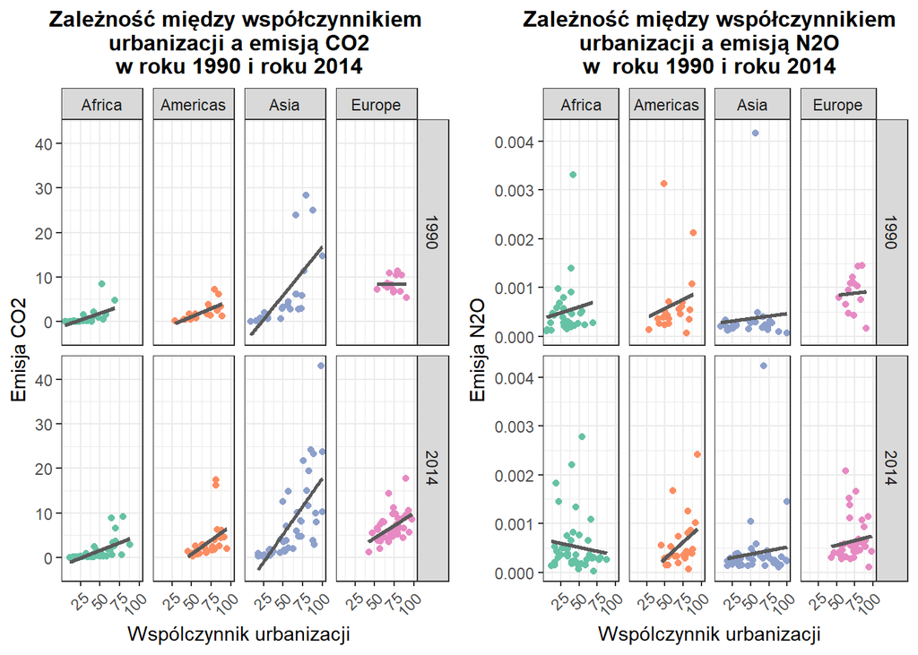

```r
urban_CO2<-filter(dane, rok%in%c(1990, 2014)) %>%
  ggplot(aes(x = urban,
             y = CO2,
             col = kontynent)) +
  scale_color_brewer(palette = "Set2") +
  geom_point() +
  geom_smooth(method = "lm", se = FALSE, col = "gray35") +
  labs(x = "Wspólczynnik urbanizacji",
       y = "Emisja CO2",
       title="Zależność między współczynnikiem
urbanizacji a emisją CO2
w roku 1990 i roku 2014") +
  theme_bw()+
  theme(legend.position = "none",
        axis.text.x = element_text(angle = 45, hjust = 1),
        plot.title = element_text(size = 12, face = "bold", hjust = 0.5)) +
  facet_grid(rok~kontynent)

urban_nitr<-filter(dane, rok%in%c(1990, 2014)) %>%
  ggplot(aes(x = urban,
             y = nitrous_per_capita_individual,
             col = kontynent)) +
  scale_color_brewer(palette = "Set2") +
  geom_point() +
  geom_smooth(method = "lm", se = FALSE, col = "gray35") +
  labs(x = "Wspólczynnik urbanizacji",
       y = "Emisja N2O",
       title="Zależność między współczynnikiem
urbanizacji a emisją N2O
w  roku 1990 i roku 2014") +
  theme_bw()+
  theme(legend.position = "none",
        axis.text.x = element_text(angle = 45, hjust = 1),
        plot.title = element_text(size = 12, face = "bold", hjust = 0.5)) +
  facet_grid(rok~kontynent)

plot_grid(urban_CO2, urban_nitr, nrow = 1)
```

```r
cor(dane$urban, dane$CO2)
```

```
## [1] 0.6350029
```

```r
cor(dane$urban, dane$nitrous_per_capita_individual)
```

```
## [1] 0.1696858
```

```r
najwyzsza_emisja_CO2 <- dane %>%
  filter(rok == 2014) %>%
  group_by(kontynent) %>%
  filter(CO2 == max(CO2)) %>%
  select(kontynent, kraj, CO2)

urban_CO2 <- dane %>%
  filter(rok == 2014) %>%
  group_by(kontynent, kraj) %>%
  filter(CO2 == max(CO2)) %>%
  select(kontynent, kraj, urban) %>%
  distinct()

max_emisja_CO2 <- najwyzsza_emisja_CO2 %>%
  left_join(urban_CO2, by = c("kontynent", "kraj"))

max_emisja_CO2
```

| kontynent | kraj | CO2 | urban |
| --- | --- | --- | --- |
| Africa | Libya | 9.23 | 79.0 |
| Europe | Luxembourg | 17.70 | 89.9 |
| Asia | Qatar | 43.10 | 98.9 |
| Americas | USA | 17.50 | 81.5 |

```r
najwyzsza_emisja_nitr <- dane %>%
  group_by(kontynent) %>%
  filter(nitrous_per_capita_individual == max(nitrous_per_capita_individual)) %>%
  select(kontynent, kraj, nitrous_per_capita_individual)

urban_nitr <- dane %>%
  group_by(kontynent, kraj) %>%
  filter(nitrous_per_capita_individual == max(nitrous_per_capita_individual)) %>%
  filter(rok == max(rok)) %>%
  select(kontynent, kraj, urban) %>%
  distinct()

max_emisja_nitr <- najwyzsza_emisja_nitr %>%
  left_join(urban_nitr, by = c("kontynent", "kraj"))

max_emisja_nitr
```

| kontynent | kraj | nitrous_per_capita_individual | urban |
| --- | --- | --- | --- |
| Americas | Paraguay | 0.003128079 | 48.7 |
| Africa | Cameroon | 0.004765625 | 42.0 |
| Europe | Ireland | 0.002989130 | 58.7 |
| Asia | Mongolia | 0.004244898 | 57.1 |

Wszystkie te państwa łączy najwyższa na kontynencie emisja podtlenku azotu oraz raczej średnia wartość współczynnika urbanizacji (średnia wynosi 58,66). Dlatego mogę stwierdzić, że współczynnik urbanizacji nie wpływa na emisję podtlenku potasu, Pozostaje mi szukać innych czynników, które mogą wpływać na emisję tego gazu cieplarnianego. Podsumowując, uważam, że współczynnik urbanizacji wpływa na emisję dwutlenku węgla poprzez to, że w obszarach miejskich zużywa się więcej energii, istnieje większe natężenie ruchu oraz obszary miejskie zazwyczaj koncentrują przemysł. Jednak nie znalazłam powiązań między współczynnikiem urbanizacji a emisją podtlenku azotu.

### Hipoteza 5

#### Korelacja między odsetkiem terenów leśnych a emisją CO2 i podtlenku azotu. Przeprowadzenie analizy, aby sprawdzić, czy istnieje tendencja, że kraje z mniejszym udziałem powierzchni leśnych generują więcej CO2.

Jak większość wie, lasy są bardzo istotne w kwestii emisji dwutlenku węgla, ponieważ podczas procesu fotosyntezy pochłaniają one ten gaz cieplarniany. Dlatego w przypadku dwutlenku węgla uważam, że państwa posiadające więcej terenów leśnych mogą emitować mniej tego gazu. Jeśli chodzi o podtlenek azotu, to jestem ciekawa, czy udział terenów leśnych może mieć też wpływ na jego emisję.

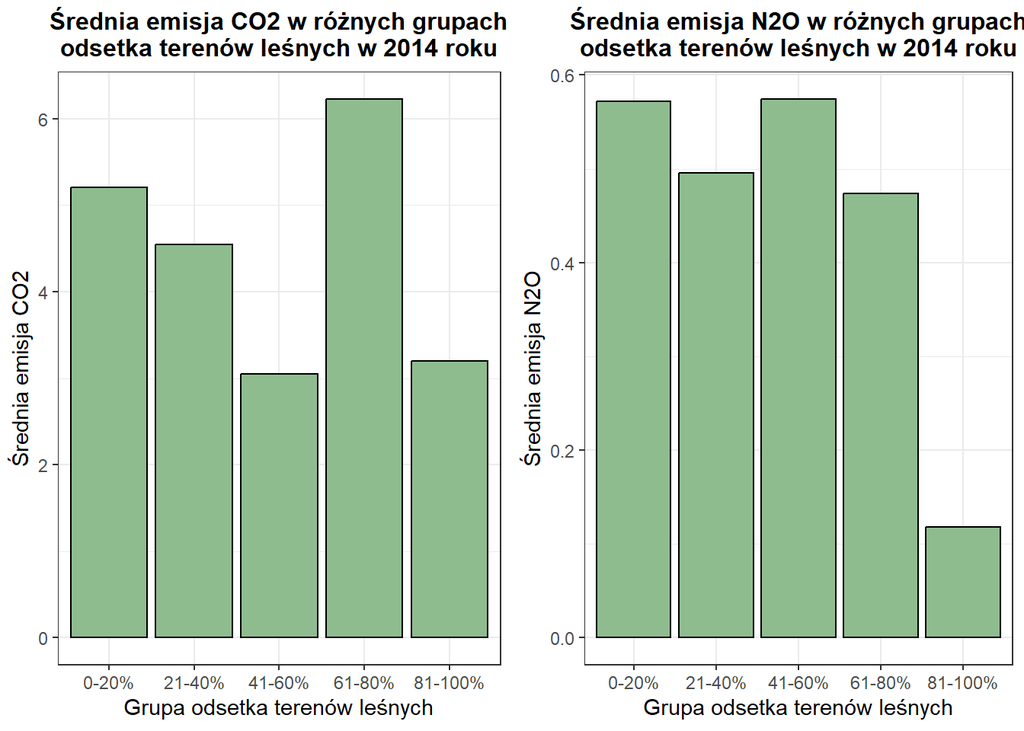

```r
woods_data <- dane_2014 %>%
  mutate(group = cut(woods, breaks = c(0, 20, 40, 60, 80, 100), labels = c("0-20%", "21-40%", "41-60%", "61-80%", "81-100%"))) %>%
  na.omit()

woods_CO2 <- ggplot(woods_data, aes(x = group, y = CO2)) +
  stat_summary(fun = mean, geom = "bar", fill = "darkseagreen", position = "dodge", colour = "black") +
  labs(
    title = "Średnia emisja CO2 w różnych grupach
odsetka terenów leśnych w 2014 roku",
    x = "Grupa odsetka terenów leśnych",
    y = "Średnia emisja CO2"
  ) +
  theme_bw() +
  theme(plot.title = element_text(size = 12, face = "bold", hjust = 0.5))

woods_nitr <- ggplot(woods_data, aes(x = group, y = nitrous_per_capita_individual)) +
  stat_summary(fun = mean, geom = "bar", fill = "darkseagreen", position = "dodge", colour = "black") +
  labs(
    title = "Średnia emisja N2O w różnych grupach
odsetka terenów leśnych w 2014 roku",
    x = "Grupa odsetka terenów leśnych",
    y = "Średnia emisja N2O"
  ) +
  theme_bw() +
  theme(plot.title = element_text(size = 12, face = "bold",hjust = 0.5)) +
 scale_y_continuous(labels = scales::number_format(scale = 1e3))

plot_grid(woods_CO2, woods_nitr,  nrow = 1)
```

Kolejne bardzo ciekawe wykresy, zacznę od tego z emisją dwutlenku węgla. Dane raczej pokazywałyby, że mniejsza wartość terenów leśnych wpływa na większą emisję dwutlenku węgla, jednak wszystko niszczy się przy odsetku 61-80% myślę, że mogą istnieć tam jakieś wartości odstające sprawiające, że istnieje tam taka wysoka emisja CO2. Postanowiłam posortować państwa z odsetkiem terenów leśnych w tym przedziale, jednak z największą emisją dwutlenku węgla i oto co otrzymałam.

```r
countries_61_80_sorted <- woods_data %>%
  filter(group == "61-80%") %>%
  select(kraj, woods, CO2) %>%
  arrange(desc(CO2))

print(countries_61_80_sorted)
```

```
##           kraj woods    CO2
## 1       Brunei  72.1 21.800
## 2  South Korea  65.1 11.600
## 3        Japan  68.5  9.880
## 4      Finland  73.6  8.730
## 5     Slovenia  62.0  6.550
## 6       Sweden  68.7  4.460
## 7       Brazil  60.5  2.590
## 8       Bhutan  71.2  1.330
## 9  Congo, Rep.  64.5  0.656
## 10         Lao  72.8  0.653
## 11      Zambia  61.8  0.277
```

Przejdę teraz do podtlenku azotu. Tutaj ciężko wypatrzeć jakąś zależność. Wykres utrzymuje wysokie wartości dotyczące emisji podtlenku azotu poza odsetkiem terenów leśnych wynoszących 81-100%. Czy może to oznaczać, że państwa z większą ilością terenów leśnych produkują mniejszą ilość gazów cieplarnianych do atmosfery?

```r
countries_81_100_sorted <- woods_data %>%
  filter(group == "81-100%") %>%
  select(kraj, woods, nitrous_per_capita_individual) %>%
  arrange(desc(nitrous_per_capita_individual))

print(countries_81_100_sorted)
```

```
##                kraj woods nitrous_per_capita_individual
## 1             Gabon  91.6                  2.639594e-04
## 2           Liberia  81.0                  6.482301e-05
## 3 Equatorial Guinea  89.1                  2.607692e-05
```

Postanowiłam przeprowadzić bardzo podobną analizę co wcześniej. Podane państwa posiadają naprawę dużą ilość terenów leśnych i małą emisją podtlenku azotu. Daje mi to pewną nadzieję, że może być to jeden z oczywiście wielu czynników wpływających na emisję podtlenku azotu. A co za tym idzie możliwy wniosek, że tereny leśne mogą być odpowiedzialne za mniejszą emisję tego gazu cieplarnianego. Z posiadanej przez większość wiedzy wiemy, że tereny zielone są ważnym elementem w cyklu życia dwutlenku węgla. Jednakże, kiedy lasy są niszczone poprzez wycinkę, spalanie lub degradację, uwolnione zostaje duże ilości zgromadzonego węgla, co przyczynia się do wzrostu emisji CO2. Czy może to też mieć wpływ na ten mniej popularny gaz cieplarniany, myśle, że tak. Podsumowując, mogę stwierdzić z posiadanej ogólnie wiedzy i wniosków wyciągniętych z analizy, że ilość terenów leśnych ma wpływ na emisję gazów cieplarnianych.

### Hipoteza 6

#### Związek między wydobyciem surowców a emisją CO2 i N2O. Analiza mająca na celu zrozumienie, czy państwa o większym wydobyciu surowców mają tendencję do większej emisji gazów cieplarnianych.

Tym razem przeprowadzę trochę inną analizę. Do obu wykresów wybiorę losowe państwa, które wydobywają dużo i mało surowców, następnie sprawdzę, czy istnieje zależność między wydobyciem surowców a emisją poszczególnych gazów cieplarnianych. Według mnie większe wydobycie surowców wiąże się z większą emisją gazów cieplarnianych.

Kraje wydobywające dużo surowców: Bahrajn, Arabia Saudyjka i Zjednoczone Emiraty Arabskie. Kraje wydobywające mało surowców: Nepal, Irak i Jemen. Aby ułatwić odczytywanie wykresu, państwa z dużym wydobyciem będą oznaczone kolorem czerwonym a te z małym zielonym.

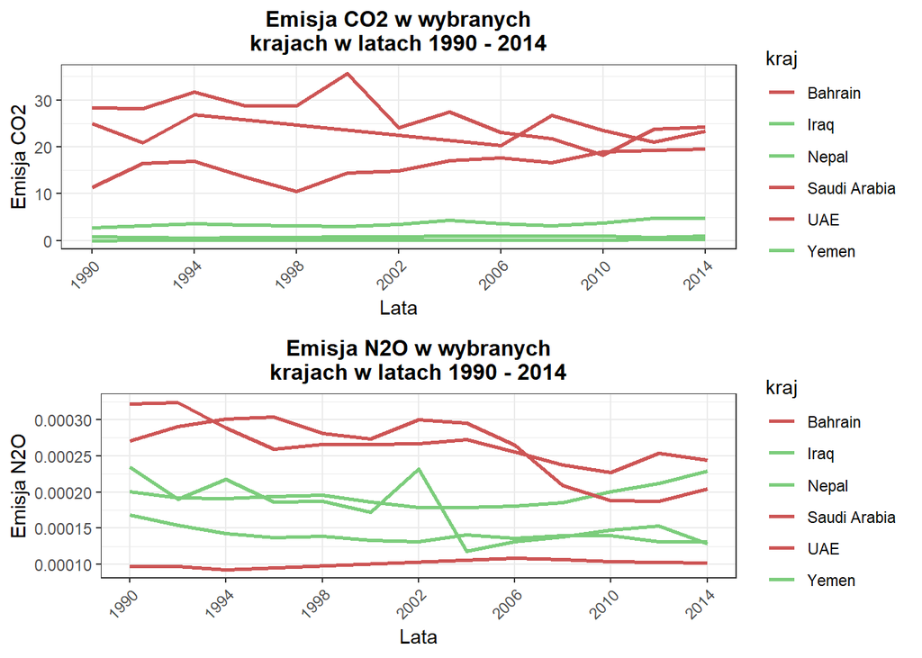

```r
dane_material <- dane %>%
  filter(kraj %in% c("Bahrain", "Saudi Arabia", "UAE", "Nepal", "Iraq", "Yemen"))

material_CO2 <- ggplot(data = dane_material, aes(x = rok, y = CO2, group = kraj, color = kraj)) +
  geom_line(linewidth = 1) +
  scale_x_discrete(breaks = c(1990, 1994, 1998, 2002, 2006, 2010, 2014)) +
  xlab("Lata") +
  ylab("Emisja CO2") +
  ggtitle("Emisja CO2 w wybranych\nkrajach w latach 1990 - 2014") +
  theme_bw() +
  theme(axis.text.x = element_text(angle = 45, hjust = 1),
        plot.title = element_text(size = 12, face = "bold", hjust = 0.5)) +
  scale_color_manual(values = c("indianred3", "palegreen3", "palegreen3", "indianred3", "indianred3", "palegreen3"))


material_nitr <- ggplot(data = dane_material, aes(x = rok, y = nitrous_per_capita_individual, group = kraj, color = kraj)) +
  geom_line(linewidth = 1) +
  scale_x_discrete(breaks = c(1990, 1994, 1998, 2002, 2006, 2010, 2014)) +
  xlab("Lata") +
  ylab("Emisja N2O") +
  ggtitle("Emisja N2O w wybranych\nkrajach w latach 1990 - 2014") +
  theme_bw() +
  theme(axis.text.x = element_text(angle = 45, hjust = 1),
        plot.title = element_text(size = 12, face = "bold", hjust = 0.5)) +
  scale_color_manual(values = c("indianred3", "palegreen3", "palegreen3", "indianred3", "indianred3", "palegreen3"))

plot_grid(material_CO2, material_nitr, labels = NULL, nrow = 2)
```

### Hipoteza 7

#### Zależność między udziałem przemysłu i rolnictwa w PKB a wykorzystaniem odnawialnej energii. Który z tych czynników przyczynia się do większego wykorzystywania źródeł odnawialnej energii przez wybrane państwa.

```r
top_industry_countries <- dane %>%
  filter(rok == 2014) %>%
  top_n(40, industry) %>%
  arrange(desc(industry)) %>%
  select(kraj, renewable)

bottom_industry_countries <- dane %>%
  filter(rok == 2014) %>%
  arrange(industry) %>%
  slice_head(n = 40) %>%
  select(kraj, renewable)

top_agriculture_countries <- dane %>%
  filter(rok == 2014) %>%
  top_n(40, agriculture) %>%
  arrange(desc(agriculture)) %>%
  select(kraj, renewable)

bottom_agriculture_countries <- dane %>%
  filter(rok == 2014) %>%
  arrange(agriculture) %>%
  slice_head(n = 40) %>%
  select(kraj, renewable)

combined_summary_all <- bind_rows(
  bind_rows(
    dane %>%
      filter(rok == 2014, kraj %in% top_industry_countries$kraj) %>%
      summarize(
        srednia = mean(renewable, na.rm = TRUE),
        mediana= median(renewable, na.rm = TRUE),
        min = min(renewable, na.rm = TRUE),
        max = max(renewable, na.rm = TRUE),
        odchylenie_standardowe = sd(renewable, na.rm = TRUE)
      ) %>%
      mutate(Kategoria = "Najwyższy przemysł"),

    dane %>%
      filter(rok == 2014, kraj %in% bottom_industry_countries$kraj) %>%
      summarize(
        srednia = mean(renewable, na.rm = TRUE),
        mediana = median(renewable, na.rm = TRUE),
        min = min(renewable, na.rm = TRUE),
        max = max(renewable, na.rm = TRUE),
        odchylenie_standardowe = sd(renewable, na.rm = TRUE)
      ) %>%
      mutate(Kategoria = "Najniższy przemysł")
  ),

  bind_rows(
    dane %>%
      filter(rok == 2014, kraj %in% top_agriculture_countries$kraj) %>%
      summarize(
        srednia= mean(renewable, na.rm = TRUE),
        mediana = median(renewable, na.rm = TRUE),
        min = min(renewable, na.rm = TRUE),
        max = max(renewable, na.rm = TRUE),
        odchylenie_standardowe = sd(renewable, na.rm = TRUE)
      ) %>%
      mutate(Kategoria = "Najwyższe rolnictwo"),

    dane %>%
      filter(rok == 2014, kraj %in% bottom_agriculture_countries$kraj) %>%
      summarize(
        srednia= mean(renewable, na.rm = TRUE),
        mediana = median(renewable, na.rm = TRUE),
        min = min(renewable, na.rm = TRUE),
        max = max(renewable, na.rm = TRUE),
        odchylenie_standardowe = sd(renewable, na.rm = TRUE)
      ) %>%
      mutate(Kategoria = "Najniższe rolnictwo")
  )
)
combined_summary_all <- combined_summary_all %>%
  select(Kategoria, everything())

combined_summary_all
```

| Kategoria | srednia | mediana | min | max | odchylenie_standardowe |
| --- | --- | --- | --- | --- | --- |
| Najwyższy przemysł | 27.17185 | 8.195 | 0 | 100.0 | 35.22470 |
| Najniższy przemysł | 42.19050 | 41.500 | 0 | 100.0 | 35.06083 |
| Najwyższe rolnictwo | 52.59683 | 60.450 | 0 | 100.0 | 37.46973 |
| Najniższe rolnictwo | 24.00015 | 15.300 | 0 | 97.7 | 26.36604 |

### Hipoteza 8

#### Zależność między PKB per capita a użyciem odnawialnej energii. Czy państwa posiadające większą wartość produktu krajowego brutto starają się dbać o środowisko naturalne używając więcej odnawialnej energii.

Od początku projektu jestem bardzo optymistyczna i będę również teraz, uważam, że państwa z większym PKB wykorzystują więcej odnawialnej energii.

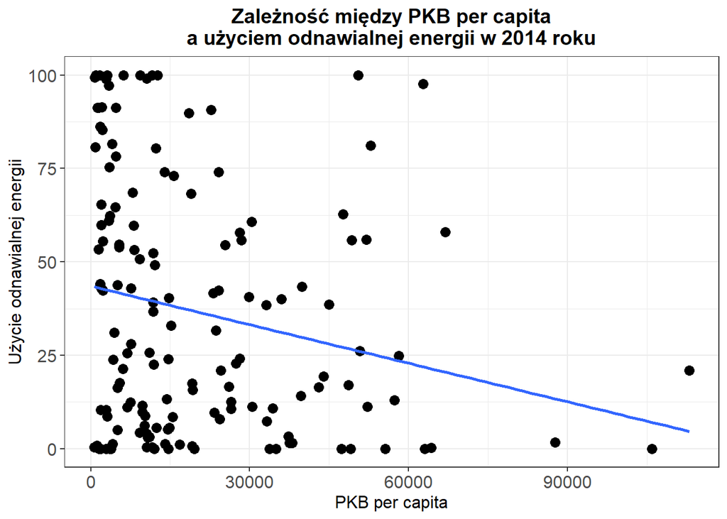

```r
PKB_renewable_14 <- ggplot(dane %>% filter(rok == 2014), aes(x = PKB, y = renewable)) +
  geom_point(size = 3) +
  geom_smooth(method = "lm", se = FALSE) +
  labs(
    title = "Zależność między PKB per capita
a użyciem odnawialnej energii w 2014 roku",
    x = "PKB per capita",
    y = "Użycie odnawialnej energii",
  ) +
  theme_bw() +
  theme(
    axis.text = element_text(size = 12),
    axis.title = element_text(size = 12),
    plot.title = element_text(size = 14, face = "bold",hjust = 0.5)
  )
PKB_renewable_14
```

```r
cor(dane$PKB, dane$renewable)
```

```
## [1] -0.257914
```

```r
max_renewable <- dane_2014 %>%
  select(kraj, renewable, PKB) %>%
  arrange(desc(renewable)) %>%
  head(10)

print(max_renewable)
```

```
##                        kraj renewable   PKB
## 1                   Albania     100.0 11600
## 2                    Bhutan     100.0  9350
## 3                  Ethiopia     100.0  1630
## 4                   Iceland     100.0 50500
## 5                       Lao     100.0  6150
## 6                     Nepal     100.0  3150
## 7                  Paraguay     100.0 12600
## 8          Congo, Dem. Rep.      99.9   999
## 9  Central African Republic      99.4   765
## 10                  Namibia      99.1 10600
```

Dodatkowo z tej ramki danych możemy zauważyć, że wysokie użycie energii odnawialnej wcale nie musi zależeć od poziomu PKB. Średnie PKB w 2014 roku wyniosło 22342 i pare państw, które klasyfikują się do tej pierwszej dziesiątki osiągają PKB mniejsze (nawet znacznie mniejsze) od średniej. Podsumowując, niestety znowu byłam zbyt optymistyczna, ale zdałam sobie sprawę, że skoro państwa o wiele niższym PKB niż średnia potrafią zdać o środowisko, to dlaczego nie potrafią tego bardziej rozwinięte państwa. Wnioskiem z tego może być konieczność uwzględnienia różnych czynników, które mogą wpływać na stosunek między PKB a wykorzystaniem odnawialnych źródeł energii, nie ograniczając się jedynie do czynnika ekonomicznego.

## Zakończenie

Wybrałam temat projektu związany ze środowiskiem naturalnym i zmianami klimatu ze względu na moje głębokie zainteresowanie tym obszarem. W czasie analizy często kierowałam się optymistycznym podejściem (czasami nawet żałosnym), co spowodowało, że kilka razy się zawiodłam. Głównym celem mojego badania było zbadanie, czy wybrane zmienne rzeczywiście mają związek z emisją gazów cieplarnianych oraz wykorzystaniem energii odnawialnej. W trakcie analizy potwierdziły się moje przypuszczenia, niektóre zmienne wykazywały istotny wpływ na emisję gazów cieplarnianych i użycie energii odnawialnej, podczas gdy inne nie miały takiego związku. Podsumowując, uważam, że podjęłam temat w interesujący sposób, co pozwoliło mi poszerzyć swoją wiedzę na temat złożoności relacji między czynnikami wpływającymi na środowisko.